# Clase 07 - Guía Regresión lineal simple y evaluación de supuestos

Curso Análisis de datos con R para Biociencias

Dr. José A. Gallardo y Dra. María Angélica Rueda.

Pontificia Universidad Católica de Valparaíso  
jose.gallardo@pucv.cl

25 January 2022

### MODELOS LINEALES

Los modelos lineales son ampliamente utilizados en acuicultura para explicar, modelar o predecir la relación lineal de una variable respuesta $Y$ con una o más variables predictoras $X_1,…,X_p$.

$$Y_{i} = \beta_{0} + \beta_{1} X_{i1} + \beta_{2} X_{i2} + ... + \beta_{p} X_{ip} + \epsilon_{i}$$

Supuestos: $Y_i$ se distribuye **normalmente**

- Si **p = 1**, el modelo es una regresión *lineal simple*.
- Si **p > 1**, el modelo es una regresión *lineal múltiple*.
- Si **p > 1** y alguna variable predictora es **categórica**, el modelo se denomina *ANCOVA*.

### PRUEBA DE HIPÓTESIS: COEFICIENTE DE REGRESIÓN E INTERCEPTO

*Prueba de hipótesis del coeficiente de regresión y el intercepto*

La hipótesis nula en ambos casos es que el coeficiente del intercepto ($β_0$) y de la pendiente ($β_1$) son iguales a 0.

$H_0:β_0 = 0$ y $H_0:β_1 = 0$

### PREDICCIÓN A PARTIR DEL MODELO DE REGRESIÓN LINEAL SIMPLE

El Coeficiente de determinación (*R²*) se calcula como el **cuadrado del coeficiente de correlación de pearson**. Este nos indica que tan buena es la predicción que el modelo hace de los datos.

El R cuadrado ajustado (*R² ajustado*) nos dice qué porcentaje de la variación de la variable dependiente es explicado por la o las variables independientes de manera conjunta. En un modelo de regresión lineal, el **R² ajustado** es una medida de bondad que considera el número de variables existentes en el modelo.

$$R^2_{ajust} =1-(1-R^2)\frac{n-1}{n-p-1}$$

donde:

$n$ = tamaño de la muestra

$p$ = cantidad de variables predictoras en el modelo

*Prueba de hipótesis del modelo completo*

La hipótesis nula es si los coeficientes son iguales a 0.

$H_0:β_j = 0$ ; $j = 1, 2,...,k$

#### **Objetivos de aprendizaje**

Los objetivos de aprendizaje de esta guía son:

**1**. - Realizar análisis de datos usando modelos lineales.

**2**. - Realizar gráficas avanzadas con ggplot2.

**3**. - Elaborar un reporte dinámico en formato pdf con **[Rmarkdown](https://rmarkdown.rstudio.com/)**.

## ESTUDIO DE CASO: RATONES DE LABORATORIO

En este estudio de caso trabajaremos con un set de datos simulado de 1000 ratones de laboratorio.

La variable respuesta se denomina **weight** y se expresa en gramos. Para este set de datos existen dos variables predictoras que se deberán analizar: 1) **Geno**: que corresponde al genotipo de los animales; 2) **Sex**: que corresponde al sexo.

La variable **Geno** tiene 3 niveles denominados **0, 1 y 2** equivalentes a los genotipos **AA, AB y BB** donde 0, 1 y 2 representan el número de alelos **B**. Esta forma numérica de representar los genotipos será util para analizar la variable **Geno** como una variable cuantitativa discreta **0, 1 y 2** o como un factor (ej. **factor(Geno)**) según sea nuestro interés. La variable **Sex** tiene dos niveles **male y female**.

### **Ejercicio 1.** Elaborar y configurar Reporte en formato .Rmd

Elabore un documento .Rmd y configure su reporte para exportar en .pdf. Instale solo las librerías que utilice para el análisis de los datos.

```r
knitr::opts_chunk$set(echo = FALSE)
library(readxl)
library(ggplot2)
library(dplyr)
library(multcomp)
```

Ejecute cada uno de los siguientes ejercicios en uno o más bloques de códigos diferentes. Sea ordenado y documente su reporte adecuadamente.

### **Ejercicio 2.** Exploratorio set de datos snp.data

Importe el set de datos **snp.data.xlsx** y transforme solo la variable **Sex** a factor, luego realice un análisis exploratorio de datos.

Incluya:

**a).** Resumen estadístico de todas las variables.

```
##      animal           weight           Geno           Sex
##  Min.   :   1.0   Min.   : 5.33   Min.   :0.000   female:500
##  1st Qu.: 250.8   1st Qu.:31.39   1st Qu.:0.000   male  :500
##  Median : 500.5   Median :43.31   Median :1.000
##  Mean   : 500.5   Mean   :43.29   Mean   :0.812
##  3rd Qu.: 750.2   3rd Qu.:55.06   3rd Qu.:1.000
##  Max.   :1000.0   Max.   :93.47   Max.   :2.000
```

**b).** Tabla de frecuencia combinada **Geno** por **Sex**, esto es importante para ver si los datos son o no balanceados.

```
##
##            0   1   2
##   female 279 197  24
##   male    72 289 139
```

```
##        0        1        2
## 32.69637 45.92583 58.25110
```

```
##   female     male
## 31.69323 54.88939
```

**c).** Histograma de la variable respuesta **weight**.

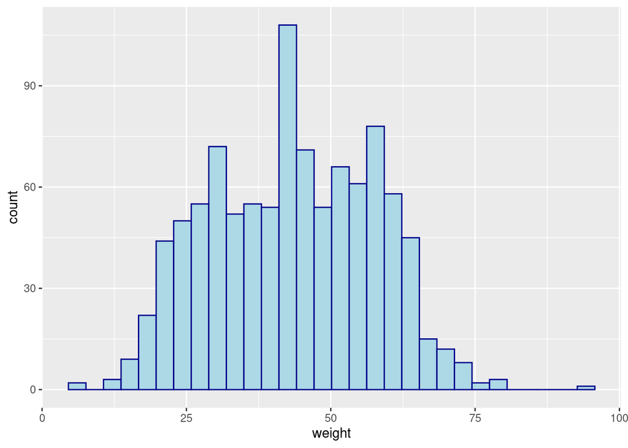

### **Ejercicio 3.** Regresión lineal simple.

**a).** Realice una gráfica de dispersión (geom_point) de **weight** en función de **Geno**, incluya el comando **geom_smooth(method=lm)** para agregar la línea de regresión a la gráfica.

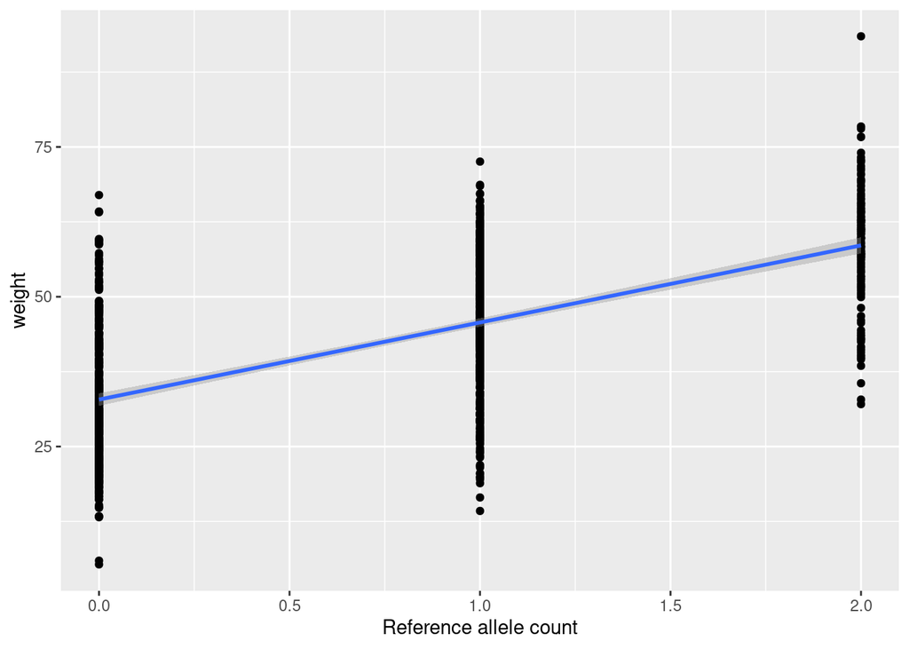

**b).** Realice un análisis de regresión lineal para investigar la asociación entre **weight** y **Geno** usando las funciones **lm()**, **summary()**. Interprete los resultados del modelo lineal y responda las siguientes preguntas. ¿Qué representa el estimador de Geno y del intercepto?. ¿La pendiente es significativamente distinta de cero?. ¿Y el intercepto?

```
##
## Call:
## lm(formula = weight ~ Geno, data = snp.data)
##
## Residuals:
##     Min      1Q  Median      3Q     Max
## -31.458  -7.802  -0.708   8.232  34.896
##
## Coefficients:
##             Estimate Std. Error t value Pr(>|t|)
## (Intercept)  32.8460     0.5330   61.62   <2e-16 ***
## Geno         12.8637     0.4997   25.74   <2e-16 ***
## ---
## Signif. codes:  0 '***' 0.001 '**' 0.01 '*' 0.05 '.' 0.1 ' ' 1
##
## Residual standard error: 10.93 on 998 degrees of freedom
## Multiple R-squared:  0.3991, Adjusted R-squared:  0.3985
## F-statistic: 662.8 on 1 and 998 DF,  p-value: < 2.2e-16
```

**c).** Realice la predicción de la media poblacional de **weight** para los genotipos AA, AB y BB y la predicción del peso **weight** de tres nuevos individuos con genotipo AA, AB y BB usando la **función predict.lm**. ¿Qué tan buena son las predicciones obtenidas? Analice el R² ajustado y los intervalos de confianza.

```
##        fit      lwr      upr
## 1 32.84601 31.80001 33.89202
## 2 45.70968 45.00670 46.41266
## 3 58.57334 57.22534 59.92135
```

```
##        fit      lwr      upr
## 1 32.84601 11.36826 54.32377
## 2 45.70968 24.24590 67.17346
## 3 58.57334 37.07877 80.06792
```

**d).** Realice una anova del modelo lineal con la función **anova()** (supone varianzas homogeneas) y compare con una anova que no supone varianzas homogeneas **oneway.test()**

```
## Analysis of Variance Table
##
## Response: weight
##            Df Sum Sq Mean Sq F value    Pr(>F)
## Geno        1  79205   79205  662.76 < 2.2e-16 ***
## Residuals 998 119269     120
## ---
## Signif. codes:  0 '***' 0.001 '**' 0.01 '*' 0.05 '.' 0.1 ' ' 1
```

```
##
##  One-way analysis of means (not assuming equal variances)
##
## data:  weight and Geno
## F = 347.42, num df = 2.00, denom df = 452.06, p-value < 2.2e-16
```

**e)** El siguiente modelo lineal permite realizar pruebas de contraste entre los tres diferentes genotipos.

lm(weight ~ -1 + factor(Geno), data = snp.data)

Compare los Betas y el $R^2$ de este modelo con el realizado en el ejercicio b.

```
##
## Call:
## lm(formula = weight ~ -1 + factor(Geno), data = snp.data)
##
## Residuals:
##     Min      1Q  Median      3Q     Max
## -31.674  -7.697  -0.687   8.047  35.218
##
## Coefficients:
##               Estimate Std. Error t value Pr(>|t|)
## factor(Geno)0  32.6964     0.5837   56.02   <2e-16 ***
## factor(Geno)1  45.9258     0.4960   92.59   <2e-16 ***
## factor(Geno)2  58.2511     0.8565   68.01   <2e-16 ***
## ---
## Signif. codes:  0 '***' 0.001 '**' 0.01 '*' 0.05 '.' 0.1 ' ' 1
##
## Residual standard error: 10.94 on 997 degrees of freedom
## Multiple R-squared:  0.9425, Adjusted R-squared:  0.9423
## F-statistic:  5445 on 3 and 997 DF,  p-value: < 2.2e-16
```

```
##
## Call:
## lm(formula = weight ~ Geno, data = snp.data)
##
## Residuals:
##     Min      1Q  Median      3Q     Max
## -31.458  -7.802  -0.708   8.232  34.896
##
## Coefficients:
##             Estimate Std. Error t value Pr(>|t|)
## (Intercept)  32.8460     0.5330   61.62   <2e-16 ***
## Geno         12.8637     0.4997   25.74   <2e-16 ***
## ---
## Signif. codes:  0 '***' 0.001 '**' 0.01 '*' 0.05 '.' 0.1 ' ' 1
##
## Residual standard error: 10.93 on 998 degrees of freedom
## Multiple R-squared:  0.3991, Adjusted R-squared:  0.3985
## F-statistic: 662.8 on 1 and 998 DF,  p-value: < 2.2e-16
```

**f)** Investigue y aplique los comandos **contrMat()** y **glht** para realizar una prueba de contrastes con ajuste de bonferroni para multiples comparaciones.

```
##
##   Simultaneous Tests for General Linear Hypotheses
##
## Multiple Comparisons of Means: Tukey Contrasts
##
##
## Fit: lm(formula = weight ~ -1 + factor(Geno), data = snp.data)
##
## Linear Hypotheses:
##            Estimate Std. Error t value Pr(>|t|)
## 1 - 0 == 0  13.2295     0.7660   17.27   <2e-16 ***
## 2 - 0 == 0  25.5547     1.0365   24.66   <2e-16 ***
## 2 - 1 == 0  12.3253     0.9898   12.45   <2e-16 ***
## ---
## Signif. codes:  0 '***' 0.001 '**' 0.01 '*' 0.05 '.' 0.1 ' ' 1
## (Adjusted p values reported -- bonferroni method)
```

### **Ejercicio 4.** Análisis de covarianza

**a).** Realice una gráfica de dispersión (geom_point) de **weight** en función de **Geno** y **Sex**, incluya el comando **geom_smooth(method=lm)** para agregar la línea de regresión a la gráfica.

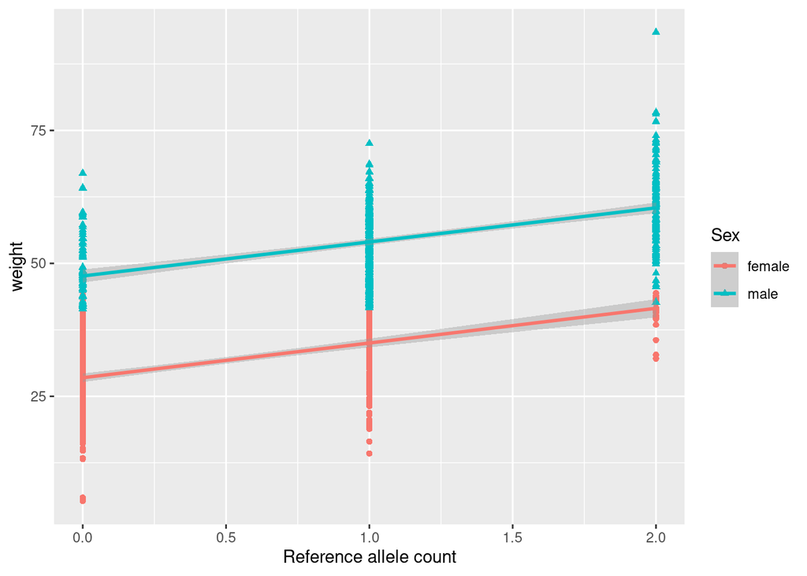

**b).** Realice un análisis de covarianza para investigar la asociación entre **weight**, **Geno** y **Sex** usando las funciones **lm()**, **summary()**.

```
##
## Call:
## lm(formula = weight ~ Geno + Sex, data = snp.data)
##
## Residuals:
##     Min      1Q  Median      3Q     Max
## -23.197  -5.004   0.081   4.800  32.985
##
## Coefficients:
##             Estimate Std. Error t value Pr(>|t|)
## (Intercept)  28.5273     0.3577   79.76   <2e-16 ***
## Geno          6.4610     0.3595   17.97   <2e-16 ***
## Sexmale      19.0353     0.4974   38.27   <2e-16 ***
## ---
## Signif. codes:  0 '***' 0.001 '**' 0.01 '*' 0.05 '.' 0.1 ' ' 1
##
## Residual standard error: 6.961 on 997 degrees of freedom
## Multiple R-squared:  0.7566, Adjusted R-squared:  0.7561
## F-statistic:  1550 on 2 and 997 DF,  p-value: < 2.2e-16
```

**c).** Interprete los resultados del modelo lineal.

### **Ejercicio 5.** Anova 2 vías con interacción

**a).** Realice gráficas del tamaño de los efectos **plot.design()** y de interacción **interaction.plot** de **Geno** y **Sex** sobre **weight**.

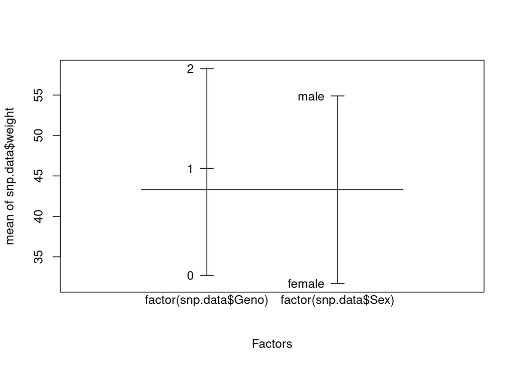

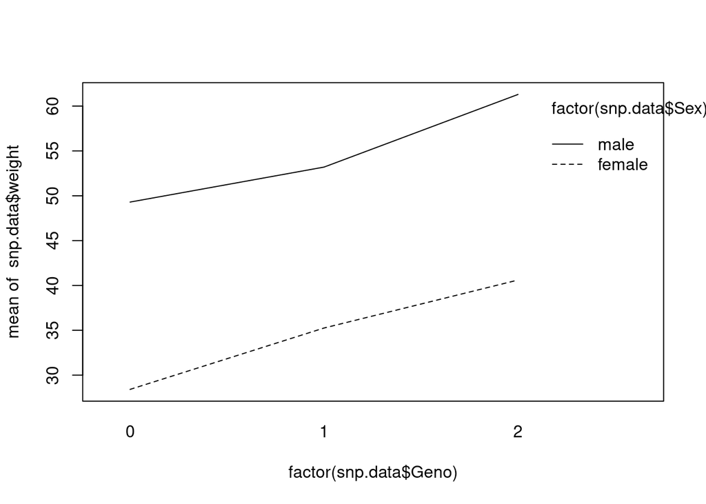

**b).** Realice un análisis de varianza con interacción para investigar la asociación entre **weight**, **Geno** y **Sex** usando las funciones **lm()**, **summary()**.

```
##
## Call:
## lm(formula = weight ~ factor(Geno) * factor(Sex), data = snp.data)
##
## Residuals:
##     Min      1Q  Median      3Q     Max
## -23.082  -5.033   0.001   4.875  32.171
##
## Coefficients:
##                               Estimate Std. Error t value Pr(>|t|)
## (Intercept)                    28.4120     0.4150  68.460  < 2e-16 ***
## factor(Geno)1                   6.8427     0.6451  10.607  < 2e-16 ***
## factor(Geno)2                  12.1925     1.4746   8.268 4.32e-16 ***
## factor(Sex)male                20.8864     0.9163  22.794  < 2e-16 ***
## factor(Geno)1:factor(Sex)male  -2.9411     1.1180  -2.631  0.00865 **
## factor(Geno)2:factor(Sex)male  -0.1929     1.7854  -0.108  0.91397
## ---
## Signif. codes:  0 '***' 0.001 '**' 0.01 '*' 0.05 '.' 0.1 ' ' 1
##
## Residual standard error: 6.932 on 994 degrees of freedom
## Multiple R-squared:  0.7593, Adjusted R-squared:  0.7581
## F-statistic: 627.2 on 5 and 994 DF,  p-value: < 2.2e-16
```

**c).** Interprete los resultados del modelo lineal.

### **Ejercicio 6.** Evalue supuestos del modelo

**a).** Evalue normalidad del modelo con interacción del ejercicio 5 usando métodos gráficos.

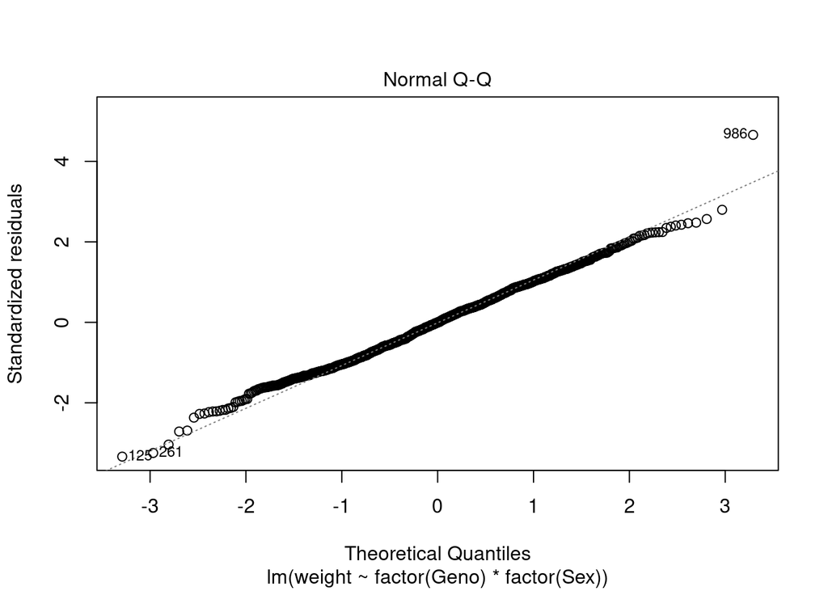

**b).** Evalue homogeneidad de varianzas usando usando métodos gráficos.

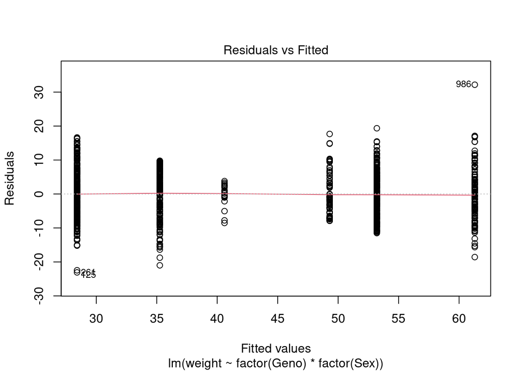